# FigureYa192breakpoint

小丫画图出品

2020-8-23

欢迎关注“小丫画图”公众号，回复“小白”，看小视频，实现点鼠标跑代码。

小丫微信: epigenomics E-mail: figureya@126.com

作者：大鱼海棠

单位：中国药科大学国家天然药物重点实验室，生物统计与计算药学研究中心

小丫编辑校验

# 需求描述

求众筹Fig 2，输入seer数据，循环cox模型，lowess平滑并绘图。

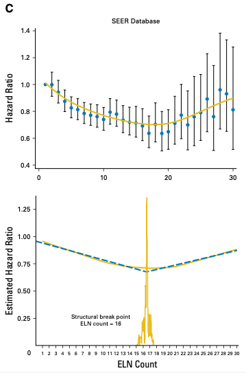

出自https://ascopubs.org/doi/full/10.1200/JCO.2016.67.5140

Fig 2. LOWESS smoother fitting curves of stage migration and overall survival and **determination of structural break points with use of the Chow test**. The fitting bandwidth was 2/3. (A) and (B) Stage migration was estimated by logistic regression after adjusting for T staging, N staging, histology, tumor location, and operation type in both cohorts. (C) and (D) Overall survival was estimated by using the Cox proportional hazards regression model after adjusting for sex, age, T staging, histology, and operation type. ELN, examined lymph node.

这里画C图，cox。A图logistic就是对OR做平滑，原理都是一样的。

# 应用场景

大样本下寻找某计数变量对预后风险的变点。

这里以SEER数据库的数据为例，也可以用于自己的数据。

# 环境设置

使用国内镜像安装包

```r
options("repos"= c(CRAN="https://mirrors.tuna.tsinghua.edu.cn/CRAN/"))
options(BioC_mirror="http://mirrors.tuna.tsinghua.edu.cn/bioconductor/")
install.packages("strucchange")
```

加载包

```r
library(survival)
library(strucchange)
Sys.setenv(LANGUAGE = "en") #显示英文报错信息
options(stringsAsFactors = FALSE) #禁止chr转成factor
```

# 输入文件的获得

如果你的数据已经整理成easy_input.csv的格式，就跳过这步，直接进入“输入文件”。

加载SEER数据，数据较大，请先解压lung.zip压缩包。

```r
dat <- read.table("lung.txt",sep = "\t",row.names = NULL,header = T,check.names = F,stringsAsFactors = F)
View(dat)
```

根据例文清洗数据

```r
dat <- dat[which(dat$`Derived AJCC Stage Group, 7th ed (2010-2015)` %in%
                   c("IA","IB","IE","IEA","IEB","II","IIA","IIB","IIE","IIEA","IIEB","III","IIIA")),]
dat <- dat[as.numeric(dat$`Regional nodes examined (1988+)`) >= 1,]

# 保留例文中部分cox回归感兴趣的协变量（我不是很清楚histology和operation type应该看哪列，结果和原文不一样）
dat <- dat[,c("Regional nodes examined (1988+)",
              "Survival months",
              "Vital status recode (study cutoff used)",
              "Age recode with single ages and 85+",
              "Derived AJCC T, 6th ed (2004-2015)")]
colnames(dat) <- c("ELN","futime","fustat","Age","Tstage")
dat <- dat[which(dat$Tstage != "TX" & dat$Age != "85+ years"),]
dat$Age <- as.numeric(gsub(" years","",dat$Age))
dat$ELN <- as.numeric(dat$ELN)
dat$Tstage <- ifelse(dat$Tstage %in% c("T0","T1","T2"), "T012","T34")
dat <- dat[which(dat$ELN <= 30),]
dat$fustat <- ifelse(dat$fustat == "Alive", 0 ,1)
dat$futime <- as.numeric(dat$futime)

# 把清洗后的数据保存到文件，便于套用
write.csv(dat, "easy_input.csv", quote = F, row.names = F)
```

# 输入文件

easy_input.csv，每行一个sample，每列一个cox回归感兴趣的协变量。

```r
dat <- read.csv("easy_input.csv")
head(dat)
```

```
##   ELN futime fustat Age Tstage
## 1  18     36      0  81   T012
## 2   4     95      0  70   T012
## 3  16     16      1  60   T012
## 4  15     31      0  73   T012
## 5  22     60      1  69   T012
## 6   1      4      1  80   T012
```

# 循环cox模型

以ELN为1作参照，分别做其他各ELN计数下的cox proportial hazards regression model

```r
ctrl <- dat[which(dat$ELN == 1),]
ELN.count <- sort(unique(dat$ELN))
Coxoutput <- NULL

for (count in ELN.count) {
  if(count == 1) {
    next()
  } else {
    treat <- dat[which(dat$ELN == count),]
    tmp <- rbind.data.frame(treat,ctrl)
    tmp$ELN <- ifelse(tmp$ELN == 1, 0 ,1)
    cox <- coxph(Surv(futime, fustat) ~ ELN + Age + Tstage, data = tmp)
    coxSummary <- summary(cox)
    Coxoutput <- rbind.data.frame(Coxoutput,
                                  data.frame(ELN.count = count,
                                             HR = as.numeric(coxSummary$coefficients[,"exp(coef)"])[1],
                                             pvalue = as.numeric(coxSummary$coefficients[,"Pr(>|z|)"])[1],
                                             lower = as.numeric(coxSummary$conf.int[,3][1]),
                                             upper = as.numeric(coxSummary$conf.int[,4][1]),
                                             stringsAsFactors = F),
                       stringsAsFactors = F)
  }
}
head(Coxoutput)
```

```
##   ELN.count        HR     pvalue     lower     upper
## 1         2 0.8825192 0.29136790 0.6996862 1.1131278
## 2         3 0.9241461 0.48781878 0.7395313 1.1548478
## 3         4 0.8580045 0.17163793 0.6888521 1.0686933
## 4         5 0.9082499 0.37852426 0.7331358 1.1251912
## 5         6 0.7920547 0.03805781 0.6354595 0.9872395
## 6         7 0.8809391 0.25545693 0.7080430 1.0960544
```

# lowess平滑并绘图

用base plot画图。如果想理解某一行代码的含义，就从plot开始到该语句一起运行。

```r
# 设置颜色
jcoBlue   <- "#2874C5"
jcoYellow <- "#EABF00"

pdf("breakpoint.pdf",width = 4.5,height = 8)
par(mfrow = c(2,1)) # 画上下两张图

## 画上图
# 计算y轴宽度
yrange <- range(c(Coxoutput$upper, Coxoutput$lower))
ymin <- floor(yrange[1] * 10)/10
ymax <- ceiling(yrange[2] * 10)/10
par(bty = "o", mgp = c(2,.6,0), mar = c(3,3,1,1), las = 1, font.axis = 1) # 基础参数
plot(x = ELN.count,
     y = c(1, Coxoutput$HR), # 补上以ELN为1时候的HR参考值（均为1）
     xaxt = "n",
     xlab = "",
     ylab = "Hazard Ratio",
     ylim = c(ymin,ymax),
     type = "p",
     pch = 19,
     col = jcoBlue,
     cex = 1.2)

# 重新补上x轴坐标
# 用seq(from=0, to=max(ELN.count), by=10)
axis(side = 1,
     at = seq(from=0, to=max(ELN.count), by=10), #生成以10为间隔的x轴label
     labels = seq(from=0, to=max(ELN.count), by=10),
     cex.axis = 0.8) # 字大小

# 添加误差线
# 垂直线
segments(ELN.count[-1], Coxoutput$lower,
         ELN.count[-1], Coxoutput$upper,
         lwd = 1.5)
# 水平封口
arrows(ELN.count[-1], Coxoutput$lower,
       ELN.count[-1], Coxoutput$upper,
       lwd = 1.5, angle = 90,
       code = 3, length = 0.05)

# 添加平滑曲线
hr.lowess <- lowess(c(1, Coxoutput$HR)~ELN.count, f = 2/3) # 原文设置f即bandwith为2/3
lines(hr.lowess, col = jcoYellow, lwd = 2)

## 画下图
# 原图靠近横坐标的黄色线，文中没有描述它代表哪个特征，因此没有画。
# 用Chow test寻找变点并绘图
f <- Fstats(hr.lowess$y ~ ELN.count)
bk <- breakpoints(f)$breakpoints # bk代表是第几个观测，只是这里恰好等于ELN的数目
# 打印变点的位置
bk
```

```
## [1] 10
```

```r
# 构建平滑点的线性回归
lm1 <- lm(hr.lowess$y[1:bk] ~ ELN.count[1:bk]) # y是第1到第bk个平滑值，x是第1到第bk个ELN的数目
lm2 <- lm(hr.lowess$y[bk:length(ELN.count)] ~ ELN.count[bk:length(ELN.count)]) # y是第bk到最后一个平滑值，x是第bk到最后一个ELN的数目

yrange <- range(Coxoutput$HR)
ymin <- floor(yrange[1] * 10)/10
ymax <- ceiling(yrange[2] * 10)/10
par(bty = "o", mgp = c(2,.6,0), mar = c(3,3,0,1), las = 1, font.axis = 1) # 基础参数
plot(hr.lowess,
     col = jcoYellow,
     lwd = 2,
     type = "l",
     ylim = c(ymin,ymax),
     xlab = "ELN Count",
     ylab = "Estimated Hazard Ratio",
     xaxt = "n")
axis(side = 1, at = seq(from=0, to=max(ELN.count), by=5), #生成以5为间隔的x轴label
     labels = seq(from=0, to=max(ELN.count), by=5),
     cex.axis = 0.8) # 字大小

lines(ELN.count[1:bk],
      predict(lm1, x = ELN.count[1:bk]),
      col = jcoBlue,
      lty = 2,
      lwd = 2)
lines(ELN.count[bk:length(ELN.count)],
      predict(lm2, x = ELN.count[bk:length(ELN.count)]),
      col = jcoBlue,
      lty = 2,
      lwd = 2)
legend("topright", paste0("Structural break point\nELN count = ",ELN.count[bk]), adj = 0.55, bty = "n")

# 关闭图像句柄
invisible(dev.off())
```

[figure not shown]